# Индивидуальный проект. Этап 2

Операционные системы

Иванов Сергей Владимирович, НПИбд-01-23

Российский университет дружбы народов, Москва, Россия

5 марта 2024

## Цель работы

Продолжить выполнение индивидуального проекта. Заполнить данные о себе на сайте в соответствии с требованиями.

## Задание

1. Разместить фотографию владельца сайта.
2. Разместить краткое описание владельца сайта (Biography).
3. Добавить информацию об интересах (Interests).
4. Добавить информацию от образовании (Education).
5. Сделать пост по прошедшей неделе.
6. Добавить пост на тему по выбору:

   Управление версиями. Git.

   Непрерывная интеграция и непрерывное развертывание (CI/CD).

# Выполнение работы

## Разместим фотографию

Помещаем её в необходимую папку и переименовываем, а старую удаляем.

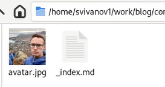

Размещение фотографии

## Краткая биография

Добавим краткую биографию о себе

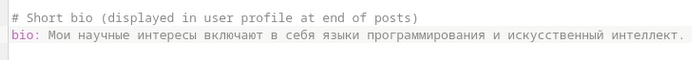

Краткая биография

## Добавление роли

Добавим свою роль (студент)

## Добавление места обучения

Добавим информацию об учебном заведении

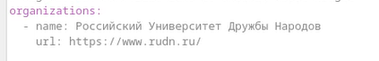

Информация о ВУЗЕ

## Интересы

Напишем о своих интересах

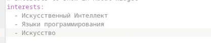

Интересы

## Образование

Добавим информацию об образовании.

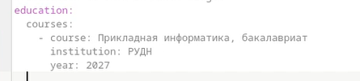

Образование

## Добавление ссылок

Добавляем ссылку на свой GitHub

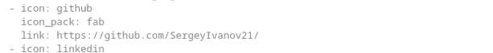

Ссылка на git

## Биография

Напишем описание владельца сайта

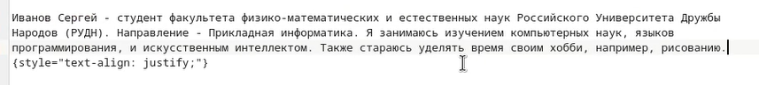

Биография

## Локальный сайт

Посмотрим, как это выглядит на локальном сайте.

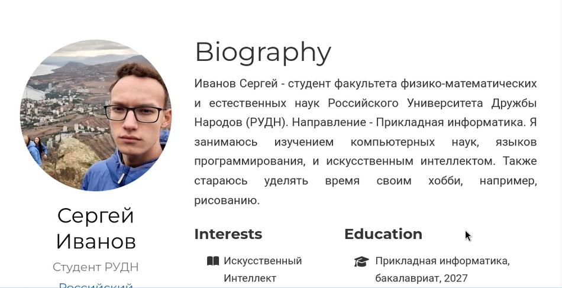

Локальный сайт

## Создаем папку для поста

Сделаем пост о прошедшей неделе. Создадим папку week.

## Создание поста

Редактируем файл index в этой папке. Пишем в нее сам текст нашего поста

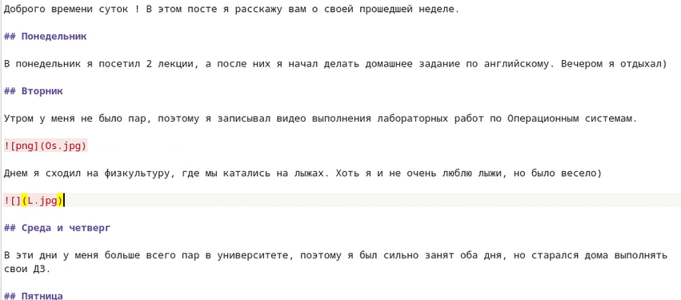

Пост на тему неделя

## Пост на тему git

Сделаем пост по теме управление версиями git.

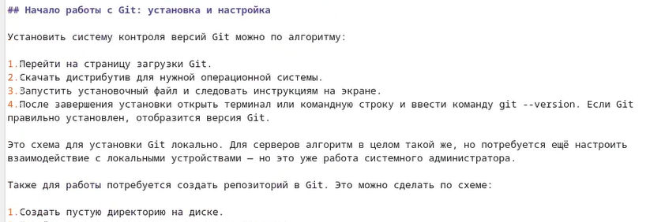

Пост на тему git

## Локальный сайт

Посмотрим на эти посты на локальном сайте и убедимся что все хорошо.

[figure not shown]

Посты на локальном сайте

## Компиляция сайта

Пишем команду ‘~/bin/hugo’ и компилируем сайт

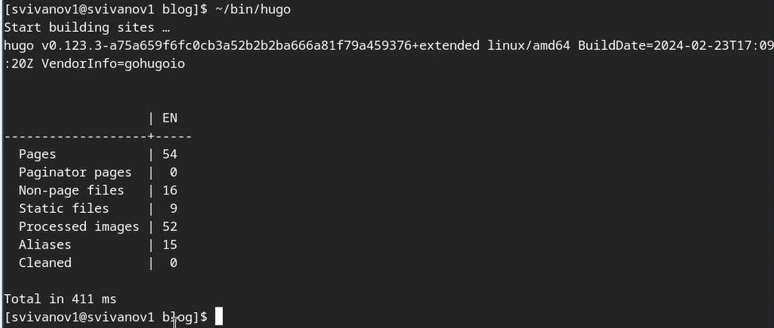

Компиляция сайта

## Отправка на сервер

Отправляем файлы папки blog на GitHub.

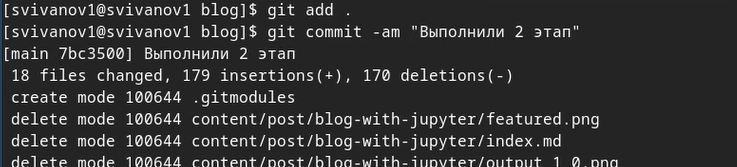

Отправляем blog на git

## Отправка на сервер

Отправляем файлы папки public на GitHub.

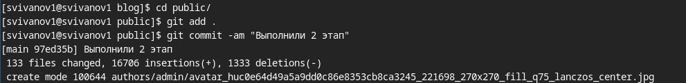

Отправляем public на git

## Проверка ссылки на сайт

Проверяем ссылку на сайт и заходим на него. Как мы видим, он работает.

[figure not shown]

Ссылка на сайт

# Вывод

## Вывод

В результате выполнения данной работы я продолжил выполнение индивидуального проекта. Заполнил данные о себе на сайте в соответствии с требованиями.